# Pengertian Hashing

Hashing adalah teknik dalam Struktur Data dan Algoritma yang digunakan untuk **menyimpan, mencari, dan mengelola data dengan sangat cepat** menggunakan suatu proses khusus yang disebut hash function.

Hashing bekerja dengan cara mengubah sebuah data menjadi sebuah nilai unik yang disebut:

- hash value,
- hash code,
- atau hash key.

Nilai tersebut kemudian digunakan sebagai alamat atau index untuk menyimpan data di dalam suatu struktur data yang disebut hash table.

Secara sederhana, hashing dapat diibaratkan seperti:

- sistem nomor loker,
- nomor rak buku,
- atau kode penyimpanan barang.

Daripada mencari data satu per satu, sistem langsung mengetahui lokasi penyimpanan data melalui hasil hashing sehingga proses pencarian menjadi jauh lebih cepat.

# Konsep Dasar Hashing

Pada hashing:

1. data dimasukkan,
2. data diproses oleh hash function,
3. menghasilkan hash value,
4. lalu data disimpan pada posisi tertentu.

Contoh sederhana:

Data:

```
"Ali"
```

Diproses menjadi:

```
Hash Value = 5
```

Artinya: data “Ali” disimpan pada index ke-5.

# Fungsi Hashing

Hashing memiliki banyak fungsi penting dalam sistem komputer dan pengolahan data.

## 1. Mempercepat Pencarian Data

Hashing memungkinkan proses pencarian data dilakukan dengan sangat cepat tanpa harus memeriksa seluruh data satu per satu.

Contoh:

- mencari username,
- mencari password,
- mencari data pelanggan.

## 2. Mempercepat Penyimpanan Data

Data dapat langsung ditempatkan pada posisi tertentu berdasarkan hasil hashing.

## 3. Mempermudah Pengelolaan Database

Hashing sering digunakan pada:

- database,
- indexing,
- caching,
- dan manajemen file.

## 4. Digunakan Dalam Sistem Keamanan

Hashing digunakan untuk:

- enkripsi password,
- autentikasi pengguna,
- verifikasi data,
- dan keamanan digital.

# Tujuan Hashing

Tujuan utama hashing adalah:

- mempercepat akses data,
- mengurangi waktu pencarian,
- meningkatkan efisiensi sistem,
- dan mempermudah pengolahan data.

Selain itu hashing juga bertujuan:

1. menghemat waktu pencarian,
2. meningkatkan performa aplikasi,
3. mengurangi proses perbandingan data,
4. membantu sistem database,
5. dan mempercepat akses informasi.

# Komponen Utama Dalam Hashing

Hashing memiliki beberapa komponen penting.

# 1. Key

Key adalah data yang digunakan sebagai input hashing.

Contoh:

```
"NIM001"
```

atau

```
"Ali"
```

# 2. Hash Function

Hash function adalah fungsi yang mengubah data menjadi hash value.

Fungsi ini menentukan:

- posisi penyimpanan data,
- dan lokasi pencarian data.

# 3. Hash Value

Hash value adalah hasil dari hash function.

Contoh:

```
Hash("Ali") = 5
```

# 4. Hash Table

Hash table adalah struktur data tempat penyimpanan hasil hashing.

Hash table biasanya berbentuk array.

# Cara Kerja Hashing Secara Umum

Proses hashing secara umum:

1. pengguna memasukkan data,
2. data diproses menggunakan hash function,
3. menghasilkan hash value,
4. hash value menentukan lokasi penyimpanan,
5. data disimpan di hash table.

Saat pencarian:

1. data dicari menggunakan hash function yang sama,
2. sistem langsung menuju lokasi data,
3. data ditemukan lebih cepat.

# Ilustrasi Sederhana Hashing

Contoh:

```
Data = "Andi"
```

Hash function menghasilkan:

```
Index = 3
```

Maka data disimpan:

```
Hash Table[3] = "Andi"
```

# Karakteristik Hashing

## 1. Cepat

Hashing memiliki kecepatan akses data yang sangat tinggi.

## 2. Efisien

Tidak perlu mencari data satu per satu.

## 3. Menggunakan Key

Hashing bekerja berdasarkan key tertentu.

## 4. Menggunakan Hash Function

Hash function menentukan lokasi penyimpanan data.

# Kelebihan Hashing

## 1. Proses Pencarian Sangat Cepat

Hashing jauh lebih cepat dibanding pencarian biasa.

## 2. Efisiensi Tinggi

Hashing mengurangi jumlah perbandingan data.

## 3. Cocok Untuk Data Besar

Hashing sangat efektif digunakan pada data dalam jumlah besar.

## 4. Digunakan Pada Banyak Sistem Modern

Hashing digunakan hampir di semua aplikasi modern.

# Kekurangan Hashing

## 1. Bisa Terjadi Collision

Collision terjadi ketika dua data menghasilkan hash value yang sama.

Contoh:

```
Data A -> index 5
Data B -> index 5
```

Hal ini dapat menyebabkan konflik penyimpanan data.

## 2. Membutuhkan Hash Function Yang Baik

Jika hash function buruk:

- data menjadi tidak merata,
- performa sistem menurun.

## 3. Penggunaan Memori

Hash table terkadang membutuhkan memori tambahan yang cukup besar.

# Collision Dalam Hashing

## Pengertian Collision

Collision adalah kondisi ketika: dua atau lebih data menghasilkan hash value yang sama.

Collision merupakan salah satu masalah utama dalam hashing.

## Contoh Collision

```
"Ali" -> index 2
"Ani" -> index 2
```

Kedua data ingin disimpan pada posisi yang sama.

# Dampak Collision

Collision dapat menyebabkan:

- pencarian lebih lambat,
- penyimpanan lebih rumit,
- dan performa sistem menurun.

# Pentingnya Hash Function

Hash function sangat penting karena menentukan:

- kecepatan sistem,
- efisiensi pencarian,
- dan kualitas hashing.

Hash function yang baik harus:

1. cepat,
2. menghasilkan distribusi data merata,
3. meminimalkan collision,
4. dan mudah dihitung.

# Penerapan Hashing Dalam Kehidupan Nyata

## 1. Login dan Password

Saat pengguna login:

- password biasanya disimpan dalam bentuk hash,
- bukan teks asli.

Hal ini meningkatkan keamanan data.

## 2. Database

Database menggunakan hashing untuk:

- indexing,
- pencarian cepat,
- manajemen data.

## 3. Caching

Hashing digunakan untuk menyimpan data sementara agar akses lebih cepat.

## 4. Mesin Pencari

Mesin pencari menggunakan hashing untuk:

- pencarian cepat,
- indexing halaman,
- pengelolaan data internet.

Contoh:

- Google
- Bing

## 5. Media Sosial

Digunakan untuk:

- autentikasi pengguna,
- penyimpanan session,
- pencarian data pengguna.

## 6. Blockchain dan Cryptocurrency

Hashing digunakan untuk:

- keamanan transaksi,
- verifikasi data,
- dan integritas blockchain.

Contoh:

- Bitcoin

# Hash Table

## Pengertian Hash Table

Hash table adalah struktur data yang digunakan untuk menyimpan data hasil hashing.

Hash table bekerja menggunakan:

- key,
- hash function,
- dan index.

Hash table memungkinkan:

- pencarian,
- penyimpanan,
- dan penghapusan data

dilakukan dengan sangat cepat.

# Kompleksitas Hashing

Pada kondisi ideal, hashing memiliki kompleksitas waktu:

## Pencarian

O(1)

## Penyimpanan

O(1)

## Penghapusan

O(1)

Artinya proses dapat dilakukan sangat cepat.

# Perbedaan Hashing Dengan Searching Biasa

| Searching Biasa | Hashing |
| --- | --- |
| Mencari satu per satu | Langsung ke lokasi data |
| Lebih lambat | Sangat cepat |
| Banyak perbandingan | Sedikit perbandingan |
| Cocok data kecil | Cocok data besar |

# Contoh Sederhana Hashing Dalam Python

Contoh menggunakan dictionary:

```
data = {
    "Ali": 90,
    "Budi": 85,
    "Citra": 95
}

print(data["Ali"])
```

Output:

```
90
```

Dictionary di Python sebenarnya menggunakan konsep hashing.

# Pentingnya Hashing Dalam Pemrograman

Hashing sangat penting karena:

- mempercepat akses data,
- meningkatkan performa aplikasi,
- mengurangi waktu pencarian,
- dan digunakan pada hampir semua sistem modern.

Tanpa hashing:

- pencarian data besar akan jauh lebih lambat,
- dan performa aplikasi dapat menurun.

# Kesimpulan

Hashing adalah teknik penting dalam Struktur Data dan Algoritma yang digunakan untuk menyimpan dan mencari data dengan sangat cepat menggunakan hash function dan hash table.

Hashing memiliki banyak kelebihan:

- cepat,
- efisien,
- dan cocok untuk data besar.

Karena kemampuannya dalam mempercepat akses data, hashing digunakan di berbagai sistem modern seperti:

- database,
- keamanan password,
- caching,
- blockchain,
- media sosial,
- dan mesin pencari internet.

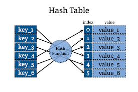

#### **Contoh Code**

```python
hash_table = [None] * 10

data = 25

index = data % 10

hash_table[index] = data

print(hash_table)
```

```
[None, None, None, None, None, 25, None, None, None, None]
```

```python
def remainder(num, data):
  return num % len(data)

def hash_table(tabel_len):
  tabel = [None for i in range(len(tabel_len))]
  return tabel

def hash_table(tabel_len):
  tabel = []
  for i in range(tabel_len):
    tabel.append(None)
  return tabel

def put_data(data, tabel):
  for i in range(len(data)):
    slot = remainder(data[i], tabel)
    tabel[slot] = data[i]
  return tabel

def searcHash(num, tabel):
  slot = remainder(num, tabel)

  return tabel[slot] == num
```

```python
tabel = hash_table(10)
print(tabel)

data = [54, 26, 93, 17]
put_data(data, tabel)

searcHash(2, tabel)
```

```
[None, None, None, None, None, None, None, None, None, None]
```

```
False
```

```python
data = [54, 26, 93, 17, 14]
size = 10

table = []
for i in range(size):
    table.append([])

def hash_func(key):
    kuadrat = key * key

    temp = kuadrat
    digit = 0
    while temp > 0:
        digit += 1
        temp = temp // 10

    if digit <= 2:
        return kuadrat % size

    buang = digit // 2 - 1
    for i in range(buang):
        kuadrat = kuadrat // 10

    tengah = kuadrat % 100
    return tengah % size

for key in data:
    index = hash_func(key)
    table[index].append(key)

print(table)
```

```
[[], [54], [], [], [93], [], [26, 14], [], [], [17]]
```